# Wednesday - Jumpstart 2025

Dan Lane

2025-08-19

# Welcome to R for Communication Research!

Welcome to the third day of Jumpstart! In Group B we will be explore how to output r code and models

## Today’s Learning Goals:

- Basics of R Markdown
- Refersher on summarizing data and outputting descriptives
- Model Output using modelsummary() package
- Output using APA Tables package

# What is R Markdown?

R Markdown is a file format that combines **Markdown text** with **R code chunks** to create dynamic documents. This very document is written in R Markdown!

# Basic Syntax

## Text Formatting

You can make text **bold** with `**bold**` or *italic* with `*italic*`.

Create lists: - Item 1 - Item 2 - Sub-item A - Sub-item B

Numbered lists: 1. First item 2. Second item 3. Third item

## Headers

Use `#` for headers. More `#` symbols = smaller headers:

```
# Header 1
## Header 2
### Header 3
```

# Code Chunks

The real power of R Markdown is combining text with code. Here’s how:

## Basic Code Chunk

This chunk shows R code and its output:

```r
# Simple calculation
x <- c(1, 2, 3, 4, 5)
mean(x)
```

```
## [1] 3
```

```r
# Create a simple dataset
data <- data.frame(
  category = c("A", "B", "C"),
  value = c(10, 15, 8)
)
print(data)
```

```
##   category value
## 1        A    10
## 2        B    15
## 3        C     8
```

## Code Chunk Options

You can control what shows up in your output:

### Show Code Only (no output)

```r
# This code shows but doesn't run
summary(mtcars)
plot(mtcars$mpg, mtcars$hp)
```

### Show Output Only (hide code)

```
##                mpg cyl disp  hp drat    wt  qsec vs am gear carb
## Mazda RX4     21.0   6  160 110 3.90 2.620 16.46  0  1    4    4
## Mazda RX4 Wag 21.0   6  160 110 3.90 2.875 17.02  0  1    4    4
## Datsun 710    22.8   4  108  93 3.85 2.320 18.61  1  1    4    1
```

### Run Code Silently (neither shows)

The secret calculation result was 4.

## Creating Tables

### Simple Table with kable()

```r
kable(head(mtcars, 5), caption = "First 5 rows of mtcars dataset")
```

First 5 rows of mtcars dataset

|  | mpg | cyl | disp | hp | drat | wt | qsec | vs | am | gear | carb |
| --- | --- | --- | --- | --- | --- | --- | --- | --- | --- | --- | --- |
| Mazda RX4 | 21.0 | 6 | 160 | 110 | 3.90 | 2.620 | 16.46 | 0 | 1 | 4 | 4 |
| Mazda RX4 Wag | 21.0 | 6 | 160 | 110 | 3.90 | 2.875 | 17.02 | 0 | 1 | 4 | 4 |
| Datsun 710 | 22.8 | 4 | 108 | 93 | 3.85 | 2.320 | 18.61 | 1 | 1 | 4 | 1 |
| Hornet 4 Drive | 21.4 | 6 | 258 | 110 | 3.08 | 3.215 | 19.44 | 1 | 0 | 3 | 1 |
| Hornet Sportabout | 18.7 | 8 | 360 | 175 | 3.15 | 3.440 | 17.02 | 0 | 0 | 3 | 2 |

### Manual Table in Markdown

| Column 1 | Column 2 | Column 3 |
| --- | --- | --- |
| Value A | 10 | TRUE |
| Value B | 20 | FALSE |
| Value C | 30 | TRUE |

# Creating Plots

R Markdown makes it easy to include plots:

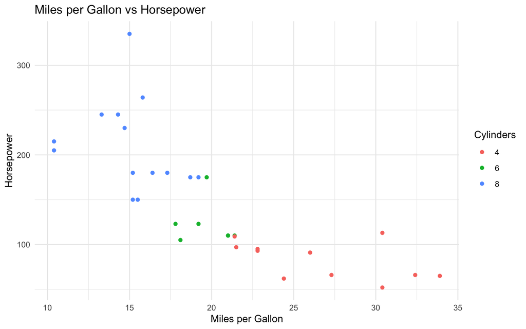

```r
# Basic scatter plot
ggplot(mtcars, aes(x = mpg, y = hp)) +
  geom_point(aes(color = factor(cyl))) +
  labs(title = "Miles per Gallon vs Horsepower",
       x = "Miles per Gallon",
       y = "Horsepower",
       color = "Cylinders") +
  theme_minimal()
```

## Controlling Figure Size

You can control plot dimensions with chunk options: - `fig.width=6, fig.height=4` - sets size in inches - `fig.align='center'` - centers the plot

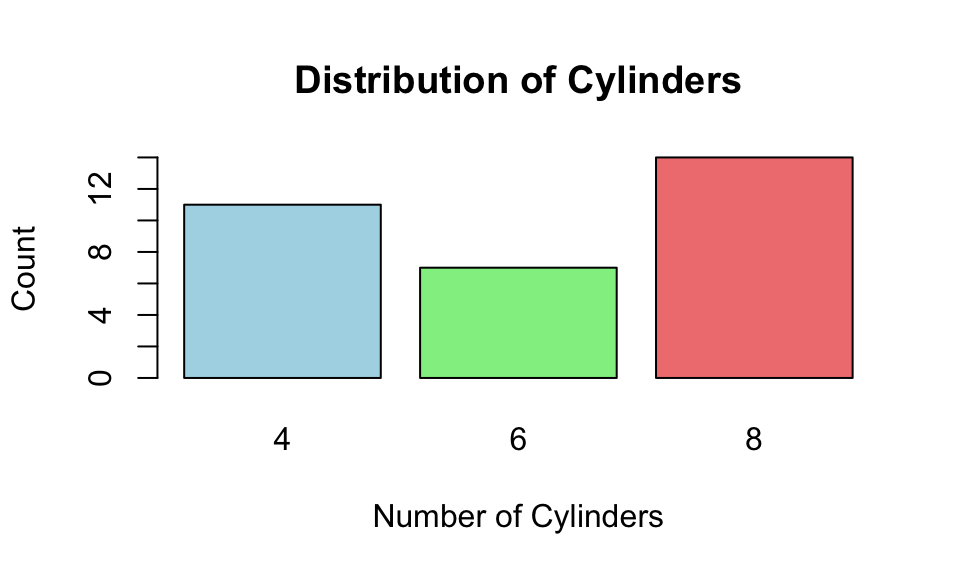

```r
barplot(table(mtcars$cyl),
        main = "Distribution of Cylinders",
        xlab = "Number of Cylinders",
        ylab = "Count",
        col = c("lightblue", "lightgreen", "lightcoral"))
```

# Inline Code

You can include R results directly in text using backticks: The mtcars dataset has 32 observations and 11 variables. The average MPG is 20.09.

# Useful Chunk Options

Here’s a reference table of common chunk options:

Common R Markdown Chunk Options

| Option | Default | Description |
| --- | --- | --- |
| echo | TRUE | Show the code |
| eval | TRUE | Run the code |
| include | TRUE | Include chunk in output |
| message | TRUE | Show messages |
| warning | TRUE | Show warnings |
| fig.width | 7 | Figure width in inches |
| fig.height | 7 | Figure height in inches |

# Mathematical Expressions

R Markdown supports LaTeX math notation:

Inline math: The formula for standard deviation is $\sigma = \sqrt{\frac{\sum(x_i - \mu)^2}{N}}$.

Display math (centered):
$$\bar{x} = \frac{\sum_{i=1}^{n} x_i}{n}$$

# Output Formats

You can change the output format in the YAML header:

```yaml
output:
  html_document    # Web page
  pdf_document     # PDF (requires LaTeX)
  word_document    # Microsoft Word
```

# Global Options Example

The setup chunk at the top sets global options:

```r
knitr::opts_chunk$set(
  echo = TRUE,        # Show code by default
  message = FALSE,    # Hide messages
  warning = FALSE,    # Hide warnings
  fig.width = 8,      # Default figure width
  fig.height = 6      # Default figure height
)
```

# Quick Reference

## Essential Chunk Options

- `{r chunk-name}` - Basic chunk
- `{r chunk-name, echo=FALSE}` - Hide code, show output
- `{r chunk-name, eval=FALSE}` - Show code, don’t run
- `{r chunk-name, include=FALSE}` - Run code, show nothing

## Knitting

- **Ctrl+Shift+K** (Windows/Linux) or **Cmd+Shift+K** (Mac) to knit
- Or click the “Knit” button in RStudio

## Pro Tips

1. Name your chunks for easier debugging
2. Use `include=FALSE` for setup chunks
3. Set global options in your setup chunk
4. Use inline code for dynamic text
5. Check your document frequently while writing

**Congratulations!** You now know the basics of R Markdown. This entire tutorial was written in R Markdown, demonstrating everything it teaches. Happy documenting!

## Review of how to use summarytools package

### 1. freq() - Frequency Tables for Categorical Variables

The `freq()` function creates detailed frequency tables for categorical variables.

```r
# Frequency table for gender
freq(D1$Gender_w1,
     main = "Gender Distribution (Wave 1)",
     style = 'rmarkdown')
```

```
## setting plain.ascii to FALSE
```

### Frequencies

#### D1$Gender_w1

**Label:** Gender (W1)  
**Type:** Factor

|  | Freq | % Valid | % Valid Cum. | % Total | % Total Cum. |
| --- | --- | --- | --- | --- | --- |
| **Female** | 727 | 53.85 | 53.85 | 53.85 | 53.85 |
| **Male** | 616 | 45.63 | 99.48 | 45.63 | 99.48 |
| **Other (describe if you wish)** | 7 | 0.52 | 100.00 | 0.52 | 100.00 |
| **<NA>** | 0 |  |  | 0.00 | 100.00 |
| **Total** | 1350 | 100.00 | 100.00 | 100.00 | 100.00 |

### Customized Frequency Table

```r
# More detailed frequency table with custom options
freq(D1$ParAct_w1,
     main = "Political Participation - Wave 1",
     style = 'rmarkdown',
     report.nas = TRUE,      # Include missing values
     totals = TRUE,          # Show totals
     display.type = TRUE,    # Display variable type
     headings = TRUE)        # Show column headings
```

```
## setting plain.ascii to FALSE
```

### Frequencies

#### D1$ParAct_w1

**Label:** Political Participation - Active (W1)  
**Type:** Numeric

|  | Freq | % Valid | % Valid Cum. | % Total | % Total Cum. |
| --- | --- | --- | --- | --- | --- |
| **1** | 1018 | 75.463 | 75.463 | 75.407 | 75.407 |
| **1.2** | 93 | 6.894 | 82.357 | 6.889 | 82.296 |
| **1.4** | 55 | 4.077 | 86.434 | 4.074 | 86.370 |
| **1.6** | 31 | 2.298 | 88.732 | 2.296 | 88.667 |
| **1.8** | 19 | 1.408 | 90.141 | 1.407 | 90.074 |
| **2** | 16 | 1.186 | 91.327 | 1.185 | 91.259 |
| **2.2** | 17 | 1.260 | 92.587 | 1.259 | 92.519 |
| **2.4** | 11 | 0.815 | 93.403 | 0.815 | 93.333 |
| **2.6** | 10 | 0.741 | 94.144 | 0.741 | 94.074 |
| **2.8** | 19 | 1.408 | 95.552 | 1.407 | 95.481 |
| **3** | 23 | 1.705 | 97.257 | 1.704 | 97.185 |
| **3.2** | 12 | 0.890 | 98.147 | 0.889 | 98.074 |
| **3.4** | 8 | 0.593 | 98.740 | 0.593 | 98.667 |
| **3.6** | 7 | 0.519 | 99.259 | 0.519 | 99.185 |
| **3.8** | 3 | 0.222 | 99.481 | 0.222 | 99.407 |
| **4** | 1 | 0.074 | 99.555 | 0.074 | 99.481 |
| **4.2** | 3 | 0.222 | 99.778 | 0.222 | 99.704 |
| **4.4** | 2 | 0.148 | 99.926 | 0.148 | 99.852 |
| **4.8** | 1 | 0.074 | 100.000 | 0.074 | 99.926 |
| **<NA>** | 1 |  |  | 0.074 | 100.000 |
| **Total** | 1350 | 100.000 | 100.000 | 100.000 | 100.000 |

### 2. descr() - Descriptive Statistics for Numerical Variables

The `descr()` function provides comprehensive descriptive statistics for numerical variables.

### Single Variable Description

```r
# Descriptive statistics for age
descr(D1$Age_w1,
      main = "Age Distribution - Wave 1",
      style = 'rmarkdown')
```

### Descriptive Statistics

#### D1$Age_w1

**Label:** Age (W1)  
**N:** 1350

|  | Age_w1 |
| --- | --- |
| **Mean** | 50.28 |
| **Std.Dev** | 17.36 |
| **Min** | 18.00 |
| **Q1** | 35.00 |
| **Median** | 52.00 |
| **Q3** | 64.00 |
| **Max** | 93.00 |
| **MAD** | 20.76 |
| **IQR** | 29.00 |
| **CV** | 0.35 |
| **Skewness** | -0.06 |
| **SE.Skewness** | 0.07 |
| **Kurtosis** | -1.00 |
| **N.Valid** | 1350.00 |
| **Pct.Valid** | 100.00 |

### Multiple Variables

```r
# Select news consumption variables for wave 1
news_vars_w1 <- D1 %>%
  dplyr::select(News_TV_w1, News_Online_w1, News_Print_w1, News_Audio_w1)

descr(news_vars_w1,
      main = "News Consumption Statistics - Wave 1",
      style = 'rmarkdown')
```

### Descriptive Statistics

#### news_vars_w1

**N:** 1350

|  | News_Audio_w1 | News_Online_w1 | News_Print_w1 | News_TV_w1 |
| --- | --- | --- | --- | --- |
| **Mean** | 2.07 | 4.19 | 1.21 | 4.25 |
| **Std.Dev** | 2.54 | 2.82 | 2.19 | 2.86 |
| **Min** | 0.00 | 0.00 | 0.00 | 0.00 |
| **Q1** | 0.00 | 1.00 | 0.00 | 1.00 |
| **Median** | 1.00 | 5.00 | 0.00 | 5.00 |
| **Q3** | 4.00 | 7.00 | 1.00 | 7.00 |
| **Max** | 7.00 | 7.00 | 7.00 | 7.00 |
| **MAD** | 1.48 | 2.97 | 0.00 | 2.97 |
| **IQR** | 4.00 | 6.00 | 1.00 | 6.00 |
| **CV** | 1.22 | 0.67 | 1.80 | 0.67 |
| **Skewness** | 0.88 | -0.33 | 1.78 | -0.41 |
| **SE.Skewness** | 0.07 | 0.07 | 0.07 | 0.07 |
| **Kurtosis** | -0.72 | -1.54 | 1.76 | -1.51 |
| **N.Valid** | 1347.00 | 1347.00 | 1346.00 | 1349.00 |
| **Pct.Valid** | 99.78 | 99.78 | 99.70 | 99.93 |

### Customized Descriptive Statistics

```r
# Political attitudes with custom statistics
political_vars <- D1 %>%
  dplyr::select(PolInt_w1, PolEff_w1, Hope_w1, Anger_w1)

descr(political_vars,
      main = "Political Attitudes - Descriptive Statistics",
      stats = c("mean", "sd", "min", "max", "med", "IQR"),
      style = 'rmarkdown',
      transpose = TRUE,       # Transpose for better readability
      headings = TRUE)
```

### Descriptive Statistics

#### political_vars

**N:** 1350

|  | Mean | Std.Dev | Min | Max | Median | IQR |
| --- | --- | --- | --- | --- | --- | --- |
| **Anger_w1** | 3.18 | 1.32 | 1.00 | 5.00 | 3.00 | 2.00 |
| **Hope_w1** | 2.97 | 1.28 | 1.00 | 5.00 | 3.00 | 2.00 |
| **PolEff_w1** | 5.49 | 1.51 | 1.00 | 7.00 | 6.00 | 2.50 |
| **PolInt_w1** | 3.64 | 1.26 | 1.00 | 5.00 | 4.00 | 2.00 |

### Grouped Descriptive Statistics

```r
# Descriptive statistics by gender
stby(D1$PolInt_w1,
   D1$Gender_w1,
   descr,
   main = "Political Interest by Gender",
   style = 'rmarkdown')
```

### Descriptive Statistics

#### PolInt_w1 by Gender_w1

**Data Frame:** D1  
**Label:** Political Interest (W1)  
**N:** 727

|  | Female | Male | Other (describe if you wish) |
| --- | --- | --- | --- |
| **Mean** | 3.52 | 3.79 | 3.43 |
| **Std.Dev** | 1.29 | 1.22 | 1.40 |
| **Min** | 1.00 | 1.00 | 2.00 |
| **Q1** | 3.00 | 3.00 | 2.00 |
| **Median** | 4.00 | 4.00 | 4.00 |
| **Q3** | 5.00 | 5.00 | 5.00 |
| **Max** | 5.00 | 5.00 | 5.00 |
| **MAD** | 1.48 | 1.48 | 1.48 |
| **IQR** | 2.00 | 2.00 | 2.50 |
| **CV** | 0.37 | 0.32 | 0.41 |
| **Skewness** | -0.42 | -0.73 | -0.03 |
| **SE.Skewness** | 0.09 | 0.10 | 0.79 |
| **Kurtosis** | -0.94 | -0.50 | -2.07 |
| **N.Valid** | 727.00 | 616.00 | 7.00 |
| **Pct.Valid** | 100.00 | 100.00 | 100.00 |

## 3. dfSummary() - Comprehensive Data Frame Summary

The `dfSummary()` function provides a complete overview of your entire dataset.

### Full Dataset Summary

```r
# Complete summary of the dataset
dfSummary(D1,
          main = "Complete Dataset Summary",
          style = 'grid',
          method = 'render',
          graph.magnif = 0.75,    # Scale down graphs
          valid.col = TRUE,       # Show valid percentages
          na.col = TRUE,          # Show missing value info
          varnumbers = FALSE,     # Don't show variable numbers
          headings = TRUE)
```

Data Frame Summary  
D1  
Dimensions: 1350 x 22  
Duplicates: 0

Variable

Label

Stats / Values

Freqs (% of Valid)

Graph

Valid

Missing

Age_w1 [numeric]

Age (W1)

Mean (sd) : 50.3 (17.4) min < med < max: 18 < 52 < 93 IQR (CV) : 29 (0.3)

74 distinct values

```
      :
      : .
```

**. : : . : : :**

: : : : : : :

: : : : : : : :

1350 (100.0%)

0 (0.0%)

Gender_w1 [factor]

Gender (W1)

1. Female
2. Male
3. Other (describe if you wi

727 (53.9%) 616 (45.6%) 7 ( 0.5%)

IIIIIIIIII IIIIIIIII

1350 (100.0%)

0 (0.0%)

Edu_w1 [factor]

1. Less than High School
2. High school graduate
3. Some college
4. 2-year college degree
5. 4-year college degree
6. Post-graduate education (

43 ( 3.2%) 399 (29.6%) 300 (22.2%) 168 (12.4%) 258 (19.1%) 182 (13.5%)

IIIII IIII II III II

1350 (100.0%)

0 (0.0%)

News_TV_w1 [numeric]

News_TV - Television, cable, or video streaming services

Mean (sd) : 4.3 (2.9) min < med < max: 0 < 5 < 7 IQR (CV) : 6 (0.7)

0 : 269 (19.9%) 1 : 97 ( 7.2%) 2 : 84 ( 6.2%) 3 : 81 ( 6.0%) 4 : 61 ( 4.5%) 5 : 137 (10.2%) 6 : 40 ( 3.0%) 7 : 580 (43.0%)

III I I I

II

IIIIIIII

1349 (99.9%)

1 (0.1%)

News_Online_w1 [numeric]

News_Online - Online news websites

Mean (sd) : 4.2 (2.8) min < med < max: 0 < 5 < 7 IQR (CV) : 6 (0.7)

0 : 245 (18.2%) 1 : 104 ( 7.7%) 2 : 118 ( 8.8%) 3 : 101 ( 7.5%) 4 : 62 ( 4.6%) 5 : 106 ( 7.9%) 6 : 54 ( 4.0%) 7 : 557 (41.4%)

III I I I

I

IIIIIIII

1347 (99.8%)

3 (0.2%)

News_Print_w1 [numeric]

News_Print - Printed newspapers or magazines

Mean (sd) : 1.2 (2.2) min < med < max: 0 < 0 < 7 IQR (CV) : 1 (1.8)

0 : 882 (65.5%) 1 : 148 (11.0%) 2 : 72 ( 5.3%) 3 : 48 ( 3.6%) 4 : 24 ( 1.8%) 5 : 43 ( 3.2%) 6 : 18 ( 1.3%) 7 : 111 ( 8.2%)

IIIIIIIIIIIII II I

I

1346 (99.7%)

4 (0.3%)

News_Audio_w1 [numeric]

News_Audio - Radio or Podcasts

Mean (sd) : 2.1 (2.5) min < med < max: 0 < 1 < 7 IQR (CV) : 4 (1.2)

0 : 633 (47.0%) 1 : 138 (10.2%) 2 : 113 ( 8.4%) 3 : 95 ( 7.1%) 4 : 65 ( 4.8%) 5 : 105 ( 7.8%) 6 : 29 ( 2.2%) 7 : 169 (12.5%)

IIIIIIIII II I I

I

II

1347 (99.8%)

3 (0.2%)

News_TV_w2 [numeric]

News_TV

Mean (sd) : 5.4 (2.9) min < med < max: 1 < 7 < 8 IQR (CV) : 6 (0.5)

1 : 206 (18.9%) 2 : 80 ( 7.3%) 3 : 60 ( 5.5%) 4 : 67 ( 6.1%) 5 : 44 ( 4.0%) 6 : 83 ( 7.6%) 7 : 35 ( 3.2%) 8 : 516 (47.3%)

III I I I

I

IIIIIIIII

1091 (80.8%)

259 (19.2%)

News_Online_w2 [numeric]

News_Online

Mean (sd) : 5.2 (2.8) min < med < max: 1 < 6 < 8 IQR (CV) : 6 (0.5)

1 : 213 (19.6%) 2 : 74 ( 6.8%) 3 : 75 ( 6.9%) 4 : 80 ( 7.4%) 5 : 59 ( 5.4%) 6 : 98 ( 9.0%) 7 : 30 ( 2.8%) 8 : 456 (42.0%)

III I I I I I

IIIIIIII

1085 (80.4%)

265 (19.6%)

News_Print_w2 [numeric]

News_Print

Mean (sd) : 2.1 (2.1) min < med < max: 1 < 1 < 8 IQR (CV) : 1 (1)

1 : 746 (68.9%) 2 : 114 (10.5%) 3 : 46 ( 4.3%) 4 : 32 ( 3.0%) 5 : 19 ( 1.8%) 6 : 26 ( 2.4%) 7 : 6 ( 0.6%) 8 : 93 ( 8.6%)

IIIIIIIIIIIII II

I

1082 (80.1%)

268 (19.9%)

News_Audio_w2 [numeric]

News_Audio

Mean (sd) : 3.1 (2.5) min < med < max: 1 < 2 < 8 IQR (CV) : 4 (0.8)

1 : 509 (47.2%) 2 : 89 ( 8.3%) 3 : 101 ( 9.4%) 4 : 73 ( 6.8%) 5 : 53 ( 4.9%) 6 : 99 ( 9.2%) 7 : 24 ( 2.2%) 8 : 130 (12.1%)

IIIIIIIII I I I

I

II

1078 (79.9%)

272 (20.1%)

PolInt_w1 [numeric]

Political Interest (W1)

Mean (sd) : 3.6 (1.3) min < med < max: 1 < 4 < 5 IQR (CV) : 2 (0.3)

1 : 97 ( 7.2%) 2 : 180 (13.3%) 3 : 283 (21.0%) 4 : 339 (25.1%) 5 : 451 (33.4%)

I II IIII IIIII IIIIII

1350 (100.0%)

0 (0.0%)

PolEff_w1 [numeric]

Political Efficacy (W1)

Mean (sd) : 5.5 (1.5) min < med < max: 1 < 6 < 7 IQR (CV) : 2.5 (0.3)

13 distinct values

```
              :
              :
              :
    .       : :
```

. . . : . : : : :

1350 (100.0%)

0 (0.0%)

SMExpPol_w1 [numeric]

Social Media Political Expression (W1)

Mean (sd) : 2.9 (1.8) min < med < max: 1 < 3 < 6 IQR (CV) : 3 (0.6)

1 : 381 (31.9%) 2 : 207 (17.4%) 3 : 232 (19.4%) 4 : 101 ( 8.5%) 5 : 86 ( 7.2%) 6 : 186 (15.6%)

IIIIII III III I I III

1193 (88.4%)

157 (11.6%)

SMExpPol_w2 [numeric]

Social Media Political Expression (W1)

Mean (sd) : 2.8 (1.8) min < med < max: 1 < 2 < 6 IQR (CV) : 3 (0.6)

1 : 337 (34.1%) 2 : 165 (16.7%) 3 : 186 (18.8%) 4 : 93 ( 9.4%) 5 : 53 ( 5.4%) 6 : 154 (15.6%)

IIIIII III III I I III

988 (73.2%)

362 (26.8%)

SMPolInf_w1 [numeric]

SM Political Info Reception (W1)

Mean (sd) : 4.5 (1.7) min < med < max: 1 < 5 < 6 IQR (CV) : 3 (0.4)

1 : 108 ( 9.1%) 2 : 104 ( 8.7%) 3 : 142 (11.9%) 4 : 120 (10.1%) 5 : 154 (12.9%) 6 : 564 (47.3%)

I I II II II IIIIIIIII

1192 (88.3%)

158 (11.7%)

SMPolInf_w2 [numeric]

SM Political Info Reception (W2)

Mean (sd) : 4.7 (1.7) min < med < max: 1 < 6 < 6 IQR (CV) : 3 (0.4)

1 : 67 ( 7.4%) 2 : 61 ( 6.7%) 3 : 102 (11.2%) 4 : 66 ( 7.2%) 5 : 125 (13.7%) 6 : 490 (53.8%)

I I II I II IIIIIIIIII

911 (67.5%)

439 (32.5%)

Conflict_1_w1 [numeric]

Conflict_1 - I hate arguments.

Mean (sd) : 5.3 (1.8) min < med < max: 1 < 6 < 7 IQR (CV) : 3 (0.3)

1 : 57 ( 4.2%) 2 : 89 ( 6.6%) 3 : 95 ( 7.0%) 4 : 149 (11.0%) 5 : 215 (15.9%) 6 : 305 (22.6%) 7 : 439 (32.5%)

I I II III IIII IIIIII

1349 (99.9%)

1 (0.1%)

ParAct_w1 [numeric]

Political Participation - Active (W1)

Mean (sd) : 1.2 (0.6) min < med < max: 1 < 1 < 4.8 IQR (CV) : 0 (0.5)

19 distinct values

: : : : : .

1349 (99.9%)

1 (0.1%)

ParAct_w2 [numeric]

Political Participation - Active (W2)

Mean (sd) : 1.2 (0.5) min < med < max: 1 < 1 < 5 IQR (CV) : 0 (0.4)

18 distinct values

: : : : :

1120 (83.0%)

230 (17.0%)

Hope_w1 [numeric]

State of America - Hope

Mean (sd) : 3 (1.3) min < med < max: 1 < 3 < 5 IQR (CV) : 2 (0.4)

1 : 192 (14.2%) 2 : 342 (25.3%) 3 : 342 (25.3%) 4 : 265 (19.6%) 5 : 209 (15.5%)

II IIIII IIIII III III

1350 (100.0%)

0 (0.0%)

Anger_w1 [numeric]

Anger about Country (W1)

Mean (sd) : 3.2 (1.3) min < med < max: 1 < 3 < 5 IQR (CV) : 2 (0.4)

9 distinct values

II

II I III I III I III

1349 (99.9%)

1 (0.1%)

### Subset Summary

```r
# Summary of wave 1 variables only
wave1_vars <- D1 %>%
  dplyr::select(ends_with("_w1"))

dfSummary(wave1_vars,
          main = "Wave 1 Variables Summary",
          style = 'grid',
          method = 'render',
          graph.magnif = 0.6,
          tmp.img.dir = "/tmp",   # Specify temp directory for images
          max.distinct.values = 10) # Limit distinct values shown
```

Data Frame Summary  
wave1_vars  
Dimensions: 1350 x 15  
Duplicates: 0

No

Variable

Label

Stats / Values

Freqs (% of Valid)

Graph

Valid

Missing

1

Age_w1 [numeric]

Age (W1)

Mean (sd) : 50.3 (17.4) min < med < max: 18 < 52 < 93 IQR (CV) : 29 (0.3)

74 distinct values

```
      :
      : .
```

**. : : . : : :**

: : : : : : :

: : : : : : : :

1350 (100.0%)

0 (0.0%)

2

Gender_w1 [factor]

Gender (W1)

1. Female
2. Male
3. Other (describe if you wi

727 (53.9%) 616 (45.6%) 7 ( 0.5%)

IIIIIIIIII IIIIIIIII

1350 (100.0%)

0 (0.0%)

3

Edu_w1 [factor]

1. Less than High School
2. High school graduate
3. Some college
4. 2-year college degree
5. 4-year college degree
6. Post-graduate education (

43 ( 3.2%) 399 (29.6%) 300 (22.2%) 168 (12.4%) 258 (19.1%) 182 (13.5%)

IIIII IIII II III II

1350 (100.0%)

0 (0.0%)

4

News_TV_w1 [numeric]

News_TV - Television, cable, or video streaming services

Mean (sd) : 4.3 (2.9) min < med < max: 0 < 5 < 7 IQR (CV) : 6 (0.7)

0 : 269 (19.9%) 1 : 97 ( 7.2%) 2 : 84 ( 6.2%) 3 : 81 ( 6.0%) 4 : 61 ( 4.5%) 5 : 137 (10.2%) 6 : 40 ( 3.0%) 7 : 580 (43.0%)

III I I I

II

IIIIIIII

1349 (99.9%)

1 (0.1%)

5

News_Online_w1 [numeric]

News_Online - Online news websites

Mean (sd) : 4.2 (2.8) min < med < max: 0 < 5 < 7 IQR (CV) : 6 (0.7)

0 : 245 (18.2%) 1 : 104 ( 7.7%) 2 : 118 ( 8.8%) 3 : 101 ( 7.5%) 4 : 62 ( 4.6%) 5 : 106 ( 7.9%) 6 : 54 ( 4.0%) 7 : 557 (41.4%)

III I I I

I

IIIIIIII

1347 (99.8%)

3 (0.2%)

6

News_Print_w1 [numeric]

News_Print - Printed newspapers or magazines

Mean (sd) : 1.2 (2.2) min < med < max: 0 < 0 < 7 IQR (CV) : 1 (1.8)

0 : 882 (65.5%) 1 : 148 (11.0%) 2 : 72 ( 5.3%) 3 : 48 ( 3.6%) 4 : 24 ( 1.8%) 5 : 43 ( 3.2%) 6 : 18 ( 1.3%) 7 : 111 ( 8.2%)

IIIIIIIIIIIII II I

I

1346 (99.7%)

4 (0.3%)

7

News_Audio_w1 [numeric]

News_Audio - Radio or Podcasts

Mean (sd) : 2.1 (2.5) min < med < max: 0 < 1 < 7 IQR (CV) : 4 (1.2)

0 : 633 (47.0%) 1 : 138 (10.2%) 2 : 113 ( 8.4%) 3 : 95 ( 7.1%) 4 : 65 ( 4.8%) 5 : 105 ( 7.8%) 6 : 29 ( 2.2%) 7 : 169 (12.5%)

IIIIIIIII II I I

I

II

1347 (99.8%)

3 (0.2%)

8

PolInt_w1 [numeric]

Political Interest (W1)

Mean (sd) : 3.6 (1.3) min < med < max: 1 < 4 < 5 IQR (CV) : 2 (0.3)

1 : 97 ( 7.2%) 2 : 180 (13.3%) 3 : 283 (21.0%) 4 : 339 (25.1%) 5 : 451 (33.4%)

I II IIII IIIII IIIIII

1350 (100.0%)

0 (0.0%)

9

PolEff_w1 [numeric]

Political Efficacy (W1)

Mean (sd) : 5.5 (1.5) min < med < max: 1 < 6 < 7 IQR (CV) : 2.5 (0.3)

13 distinct values

```
              :
              :
              :
    .       : :
```

. . . : . : : : :

1350 (100.0%)

0 (0.0%)

10

SMExpPol_w1 [numeric]

Social Media Political Expression (W1)

Mean (sd) : 2.9 (1.8) min < med < max: 1 < 3 < 6 IQR (CV) : 3 (0.6)

1 : 381 (31.9%) 2 : 207 (17.4%) 3 : 232 (19.4%) 4 : 101 ( 8.5%) 5 : 86 ( 7.2%) 6 : 186 (15.6%)

IIIIII III III I I III

1193 (88.4%)

157 (11.6%)

11

SMPolInf_w1 [numeric]

SM Political Info Reception (W1)

Mean (sd) : 4.5 (1.7) min < med < max: 1 < 5 < 6 IQR (CV) : 3 (0.4)

1 : 108 ( 9.1%) 2 : 104 ( 8.7%) 3 : 142 (11.9%) 4 : 120 (10.1%) 5 : 154 (12.9%) 6 : 564 (47.3%)

I I II II II IIIIIIIII

1192 (88.3%)

158 (11.7%)

12

Conflict_1_w1 [numeric]

Conflict_1 - I hate arguments.

Mean (sd) : 5.3 (1.8) min < med < max: 1 < 6 < 7 IQR (CV) : 3 (0.3)

1 : 57 ( 4.2%) 2 : 89 ( 6.6%) 3 : 95 ( 7.0%) 4 : 149 (11.0%) 5 : 215 (15.9%) 6 : 305 (22.6%) 7 : 439 (32.5%)

I I II III IIII IIIIII

1349 (99.9%)

1 (0.1%)

13

ParAct_w1 [numeric]

Political Participation - Active (W1)

Mean (sd) : 1.2 (0.6) min < med < max: 1 < 1 < 4.8 IQR (CV) : 0 (0.5)

19 distinct values

: : : : : .

1349 (99.9%)

1 (0.1%)

14

Hope_w1 [numeric]

State of America - Hope

Mean (sd) : 3 (1.3) min < med < max: 1 < 3 < 5 IQR (CV) : 2 (0.4)

1 : 192 (14.2%) 2 : 342 (25.3%) 3 : 342 (25.3%) 4 : 265 (19.6%) 5 : 209 (15.5%)

II IIIII IIIII III III

1350 (100.0%)

0 (0.0%)

15

Anger_w1 [numeric]

Anger about Country (W1)

Mean (sd) : 3.2 (1.3) min < med < max: 1 < 3 < 5 IQR (CV) : 2 (0.4)

9 distinct values

II

II I III I III I III

1349 (99.9%)

1 (0.1%)

### Customized dfSummary

```r
# Focus on key demographic and political variables
key_vars <- D1 %>%
  dplyr::select(Age_w1, Gender_w1, Edu_w1, PolInt_w1, PolEff_w1, ParAct_w1)

dfSummary(key_vars,
          main = "Key Variables Summary",
          method = 'render',
          style = 'grid',
          plain.ascii = FALSE,
          graph.col = TRUE,       # Include frequency graphs
          valid.col = TRUE,
          na.col = TRUE,
          col.widths = c(150, 100, 300, 100, 100, 100)) # Custom column widths
```

```
## text graphs are displayed; set 'tmp.img.dir' parameter to activate png graphs
```

### Data Frame Summary

#### key_vars

**Dimensions:** 1350 x 6  
**Duplicates:** 59

| No | Variable | Label | Stats / Values | Freqs (% of Valid) | Graph | Valid | Missing |
| --- | --- | --- | --- | --- | --- | --- | --- |
| 1 | Age_w1 [numeric] | Age (W1) | Mean (sd) : 50.3 (17.4) min < med < max: 18 < 52 < 93 IQR (CV) : 29 (0.3) | 74 distinct values | : : . . : : . : : : : : : : : : : : : : : : : : : : : | 1350 (100.0%) | 0 (0.0%) |
| 2 | Gender_w1 [factor] | Gender (W1) | 1. Female 2. Male 3. Other (describe if you wi | 727 (53.9%) 616 (45.6%) 7 ( 0.5%) | IIIIIIIIII IIIIIIIII | 1350 (100.0%) | 0 (0.0%) |
| 3 | Edu_w1 [factor] |  | 1. Less than High School 2. High school graduate 3. Some college 4. 2-year college degree 5. 4-year college degree 6. Post-graduate education ( | 43 ( 3.2%) 399 (29.6%) 300 (22.2%) 168 (12.4%) 258 (19.1%) 182 (13.5%) | IIIII IIII II III II | 1350 (100.0%) | 0 (0.0%) |
| 4 | PolInt_w1 [numeric] | Political Interest (W1) | Mean (sd) : 3.6 (1.3) min < med < max: 1 < 4 < 5 IQR (CV) : 2 (0.3) | 1 : 97 ( 7.2%) 2 : 180 (13.3%) 3 : 283 (21.0%) 4 : 339 (25.1%) 5 : 451 (33.4%) | I II IIII IIIII IIIIII | 1350 (100.0%) | 0 (0.0%) |
| 5 | PolEff_w1 [numeric] | Political Efficacy (W1) | Mean (sd) : 5.5 (1.5) min < med < max: 1 < 6 < 7 IQR (CV) : 2.5 (0.3) | 13 distinct values | : : : . : : . . . : . : : : : | 1350 (100.0%) | 0 (0.0%) |
| 6 | ParAct_w1 [numeric] | Political Participation - Active (W1) | Mean (sd) : 1.2 (0.6) min < med < max: 1 < 1 < 4.8 IQR (CV) : 0 (0.5) | 19 distinct values | : : : : : . | 1349 (99.9%) | 1 (0.1%) |

## Advanced Tips for summarytools in R Markdown Output

### 1. Print with Custom Options

```r
# Create summary and print with specific options
my_summary <- dfSummary(D1 %>% dplyr::select(Age_w1, Gender_w1, PolInt_w1))

print(my_summary,
      method = 'render',
      table.classes = 'table table-striped table-bordered',
      bootstrap.css = FALSE,
      escape = FALSE)
```

Data Frame Summary

D1

**Dimensions**: 1350 x 3  
**Duplicates**: 824

| **No** | **Variable** | **Label** | **Stats / Values** | **Freqs (% of Valid)** | **Graph** | **Valid** | **Missing** |
| --- | --- | --- | --- | --- | --- | --- | --- |
| 1 | Age_w1 [numeric] | Age (W1) | Mean (sd) : 50.3 (17.4) min ≤ med ≤ max: 18 ≤ 52 ≤ 93 IQR (CV) : 29 (0.3) | 74 distinct values |  | 1350 (100.0%) | 0 (0.0%) |
| 2 | Gender_w1 [factor] | Gender (W1) | 1. Female 2. Male 3. Other (describe if you wi | 727 ( 53.9% ) 616 ( 45.6% ) 7 ( 0.5% ) |  | 1350 (100.0%) | 0 (0.0%) |
| 3 | PolInt_w1 [numeric] | Political Interest (W1) | Mean (sd) : 3.6 (1.3) min ≤ med ≤ max: 1 ≤ 4 ≤ 5 IQR (CV) : 2 (0.3) | 1 : 97 ( 7.2% ) 2 : 180 ( 13.3% ) 3 : 283 ( 21.0% ) 4 : 339 ( 25.1% ) 5 : 451 ( 33.4% ) |  | 1350 (100.0%) | 0 (0.0%) |

Generated by summarytools 1.0.1 ([R](https://www.r-project.org/) version 4.3.1)  
2025-09-14

### 2. Save Summaries to HTML

```r
# Save frequency table to HTML file
freq_table <- freq(D1$Gender_w1, style = 'rmarkdown')
print(freq_table, file = "gender_frequency.html")

# Save descriptive stats to HTML
desc_stats <- descr(D1$Age_w1, style = 'rmarkdown')
print(desc_stats, file = "age_descriptives.html")
```

### 3. Comparative Analysis Across Waves

```r
# Compare political participation across waves
par_comparison <- D1 %>%
  dplyr::select(ParAct_w1, ParAct_w2) %>%
  dfSummary(main = "Political Participation: Wave 1 vs Wave 2",
            style = 'multiline')

print(par_comparison)
```

Data Frame Summary  
D1  
Dimensions: 1350 x 2  
Duplicates: 1229

| No | Variable | Label | Stats / Values | Freqs (% of Valid) | Graph | Valid | Missing |
| --- | --- | --- | --- | --- | --- | --- | --- |
| 1 | ParAct_w1 [numeric] | Political Participation - Active (W1) | Mean (sd) : 1.2 (0.6) min < med < max: 1 < 1 < 4.8 IQR (CV) : 0 (0.5) | 19 distinct values | : : : : : . | 1349 (99.9%) | 1 (0.1%) |
| 2 | ParAct_w2 [numeric] | Political Participation - Active (W2) | Mean (sd) : 1.2 (0.5) min < med < max: 1 < 1 < 5 IQR (CV) : 0 (0.4) | 18 distinct values | : : : : : | 1120 (83.0%) | 230 (17.0%) |

#### Best Practices for SummaryTools in R Markdown

1. **Set global options** in your setup chunk for consistent styling
2. **Use `results='asis'`** in chunk options for proper HTML rendering
3. **Customize table classes** for Bootstrap styling if using HTML output
4. **Control graph size** with `graph.magnif` parameter
5. **Handle missing values** explicitly with `na.col = TRUE`
6. **Use meaningful titles** with the `main` parameter
7. **Group related variables** for focused analysis

#### Styling Tips

- Use `style = 'multiline'` for all functions
- Set `bootstrap.css = FALSE` in global options
- Adjust `graph.magnif` to control plot sizes
- Use `transpose = TRUE` for better readability of descriptive statistics
- Customize column widths with `col.widths` parameter

# Outputting regression models

## Introduction to modelsummary

The `modelsummary()` function creates beautiful, publication-ready tables from statistical models. It supports dozens of model types and multiple output formats (HTML, LaTeX, Word, etc.).

## Basic Model and Data

```r
# Assuming your data D1 is loaded
# For demonstration, we'll create sample data with similar structure

# Your regression model
fit1 <- lm(SMExpPol_w1 ~ Age_w1 + Edu_w1 + Anger_w1 + Hope_w1, data = D1)
summary(fit1)
```

```
##
## Call:
## lm(formula = SMExpPol_w1 ~ Age_w1 + Edu_w1 + Anger_w1 + Hope_w1,
##     data = D1)
##
## Residuals:
##     Min      1Q  Median      3Q     Max
## -2.8396 -1.5006 -0.2975  1.1735  3.8885
##
## Coefficients:
##                                                            Estimate Std. Error
## (Intercept)                                                 0.73813    0.35203
## Age_w1                                                      0.01027    0.00302
## Edu_w1High school graduate                                  0.12215    0.29886
## Edu_w1Some college                                          0.25105    0.30288
## Edu_w12-year college degree                                 0.16113    0.31743
## Edu_w14-year college degree                                 0.50081    0.30617
## Edu_w1Post-graduate education (some or a completed degree)  0.27439    0.31727
## Anger_w1                                                    0.25750    0.04042
## Hope_w1                                                     0.19093    0.04223
##                                                            t value Pr(>|t|)
## (Intercept)                                                  2.097 0.036222 *
## Age_w1                                                       3.399 0.000698 ***
## Edu_w1High school graduate                                   0.409 0.682822
## Edu_w1Some college                                           0.829 0.407345
## Edu_w12-year college degree                                  0.508 0.611820
## Edu_w14-year college degree                                  1.636 0.102156
## Edu_w1Post-graduate education (some or a completed degree)   0.865 0.387295
## Anger_w1                                                     6.371 2.68e-10 ***
## Hope_w1                                                      4.521 6.76e-06 ***
## ---
## Signif. codes:  0 '***' 0.001 '**' 0.01 '*' 0.05 '.' 0.1 ' ' 1
##
## Residual standard error: 1.742 on 1183 degrees of freedom
##   (158 observations deleted due to missingness)
## Multiple R-squared:  0.0635, Adjusted R-squared:  0.05717
## F-statistic: 10.03 on 8 and 1183 DF,  p-value: 1.346e-13
```

# Basic modelsummary Usage

## Simple Model Table

```r
# Basic model summary with significance stars
modelsummary(fit1, stars = TRUE)
```

|  | (1) |
| --- | --- |
| (Intercept) | 0.738* |
|  | (0.352) |
| Age_w1 | 0.010*** |
|  | (0.003) |
| Edu_w1High school graduate | 0.122 |
|  | (0.299) |
| Edu_w1Some college | 0.251 |
|  | (0.303) |
| Edu_w12-year college degree | 0.161 |
|  | (0.317) |
| Edu_w14-year college degree | 0.501 |
|  | (0.306) |
| Edu_w1Post-graduate education (some or a completed degree) | 0.274 |
|  | (0.317) |
| Anger_w1 | 0.257*** |
|  | (0.040) |
| Hope_w1 | 0.191*** |
|  | (0.042) |
| Num.Obs. | 1192 |
| R2 | 0.064 |
| R2 Adj. | 0.057 |
| AIC | 4716.8 |
| BIC | 4767.6 |
| Log.Lik. | -2348.376 |
| F | 10.027 |
| RMSE | 1.74 |

+ p < 0.1, * p < 0.05, ** p < 0.01, *** p < 0.001

## Customizing the Table

```r
# More customized version
modelsummary(fit1,
             stars = TRUE,                    # Show significance stars
             title = "Predicting Social Media Political Exposure",
             notes = "Data source: Political survey Wave 1")
```

|  | (1) |
| --- | --- |
| (Intercept) | 0.738* |
|  | (0.352) |
| Age_w1 | 0.010*** |
|  | (0.003) |
| Edu_w1High school graduate | 0.122 |
|  | (0.299) |
| Edu_w1Some college | 0.251 |
|  | (0.303) |
| Edu_w12-year college degree | 0.161 |
|  | (0.317) |
| Edu_w14-year college degree | 0.501 |
|  | (0.306) |
| Edu_w1Post-graduate education (some or a completed degree) | 0.274 |
|  | (0.317) |
| Anger_w1 | 0.257*** |
|  | (0.040) |
| Hope_w1 | 0.191*** |
|  | (0.042) |
| Num.Obs. | 1192 |
| R2 | 0.064 |
| R2 Adj. | 0.057 |
| AIC | 4716.8 |
| BIC | 4767.6 |
| Log.Lik. | -2348.376 |
| F | 10.027 |
| RMSE | 1.74 |

+ p < 0.1, * p < 0.05, ** p < 0.01, *** p < 0.001  
Data source: Political survey Wave 1

# Advanced Customization

## Custom Coefficient Names

```r
# Create cleaner variable names
modelsummary(fit1,
             stars = TRUE,
             coef_rename = c(
               "(Intercept)" = "Intercept",
               "Age_w1" = "Age (Wave 1)",
               "Edu_w1" = "Education Level",
               "Anger_w1" = "Political Anger",
               "Hope_w1" = "Political Hope"
             ),
             title = "Predictors of Social Media Political Exposure")
```

|  | (1) |
| --- | --- |
| Intercept | 0.738* |
|  | (0.352) |
| Age (Wave 1) | 0.010*** |
|  | (0.003) |
| Edu_w1High school graduate | 0.122 |
|  | (0.299) |
| Edu_w1Some college | 0.251 |
|  | (0.303) |
| Edu_w12-year college degree | 0.161 |
|  | (0.317) |
| Edu_w14-year college degree | 0.501 |
|  | (0.306) |
| Edu_w1Post-graduate education (some or a completed degree) | 0.274 |
|  | (0.317) |
| Political Anger | 0.257*** |
|  | (0.040) |
| Political Hope | 0.191*** |
|  | (0.042) |
| Num.Obs. | 1192 |
| R2 | 0.064 |
| R2 Adj. | 0.057 |
| AIC | 4716.8 |
| BIC | 4767.6 |
| Log.Lik. | -2348.376 |
| F | 10.027 |
| RMSE | 1.74 |

+ p < 0.1, * p < 0.05, ** p < 0.01, *** p < 0.001

## Selecting Statistics

```r
# Customize which statistics to show
modelsummary(fit1,
             stars = TRUE,
             statistic = c("std.error", "p.value"),  # Show SE and p-values
             gof_map = c("nobs", "r.squared", "adj.r.squared", "rmse"),
             title = "Model with Custom Statistics")
```

|  | (1) |
| --- | --- |
| (Intercept) | 0.738* |
|  | (0.352) |
|  | (0.036) |
| Age_w1 | 0.010*** |
|  | (0.003) |
|  | (<0.001) |
| Edu_w1High school graduate | 0.122 |
|  | (0.299) |
|  | (0.683) |
| Edu_w1Some college | 0.251 |
|  | (0.303) |
|  | (0.407) |
| Edu_w12-year college degree | 0.161 |
|  | (0.317) |
|  | (0.612) |
| Edu_w14-year college degree | 0.501 |
|  | (0.306) |
|  | (0.102) |
| Edu_w1Post-graduate education (some or a completed degree) | 0.274 |
|  | (0.317) |
|  | (0.387) |
| Anger_w1 | 0.257*** |
|  | (0.040) |
|  | (<0.001) |
| Hope_w1 | 0.191*** |
|  | (0.042) |
|  | (<0.001) |
| Num.Obs. | 1192 |
| R2 | 0.064 |
| R2 Adj. | 0.057 |
| RMSE | 1.74 |

+ p < 0.1, * p < 0.05, ** p < 0.01, *** p < 0.001

## Multiple Output Formats

```r
# Different table styles for different outputs
modelsummary(fit1,
             stars = TRUE,
             output = "kableExtra",           # Enhanced HTML tables
             title = "Enhanced HTML Table") %>%
  kableExtra::kable_styling(bootstrap_options = c("striped", "hover"))
```

Enhanced HTML Table

|  | &nbsp;(1) |
| --- | --- |
| (Intercept) | 0.738* |
|  | (0.352) |
| Age_w1 | 0.010*** |
|  | (0.003) |
| Edu_w1High school graduate | 0.122 |
|  | (0.299) |
| Edu_w1Some college | 0.251 |
|  | (0.303) |
| Edu_w12-year college degree | 0.161 |
|  | (0.317) |
| Edu_w14-year college degree | 0.501 |
|  | (0.306) |
| Edu_w1Post-graduate education (some or a completed degree) | 0.274 |
|  | (0.317) |
| Anger_w1 | 0.257*** |
|  | (0.040) |
| Hope_w1 | 0.191*** |
|  | (0.042) |
| Num.Obs. | 1192 |
| R2 | 0.064 |
| R2 Adj. | 0.057 |
| AIC | 4716.8 |
| BIC | 4767.6 |
| Log.Lik. | −2348.376 |
| F | 10.027 |
| RMSE | 1.74 |

+ p < 0.1, * p < 0.05, ** p < 0.01, *** p < 0.001

# Comparing Multiple Models

```r
# Create additional models for comparison
fit1 <- lm(SMExpPol_w1 ~ Age_w1 + Edu_w1 + Anger_w1 + Hope_w1, data = D1)
fit2 <- lm(SMExpPol_w1 ~ Age_w1 + Edu_w1, data = D1)
fit3 <- lm(SMExpPol_w1 ~ Anger_w1 + Hope_w1, data = D1)

# Compare models side by side
modelsummary(list("Full Model" = fit1,
                  "Demographics Only" = fit2,
                  "Emotions Only" = fit3),
             stars = TRUE,
             title = "Model Comparison: Predictors of Social Media Political Exposure")
```

|  | Full Model | Demographics Only | Emotions Only |
| --- | --- | --- | --- |
| (Intercept) | 0.738* | 1.799*** | 1.338*** |
|  | (0.352) | (0.321) | (0.207) |
| Age_w1 | 0.010*** | 0.014*** |  |
|  | (0.003) | (0.003) |  |
| Edu_w1High school graduate | 0.122 | 0.277 |  |
|  | (0.299) | (0.304) |  |
| Edu_w1Some college | 0.251 | 0.409 |  |
|  | (0.303) | (0.308) |  |
| Edu_w12-year college degree | 0.161 | 0.276 |  |
|  | (0.317) | (0.323) |  |
| Edu_w14-year college degree | 0.501 | 0.699* |  |
|  | (0.306) | (0.310) |  |
| Edu_w1Post-graduate education (some or a completed degree) | 0.274 | 0.417 |  |
|  | (0.317) | (0.322) |  |
| Anger_w1 | 0.257*** |  | 0.285*** |
|  | (0.040) |  | (0.040) |
| Hope_w1 | 0.191*** |  | 0.213*** |
|  | (0.042) |  | (0.042) |
| Num.Obs. | 1192 | 1193 | 1192 |
| R2 | 0.064 | 0.025 | 0.049 |
| R2 Adj. | 0.057 | 0.020 | 0.047 |
| AIC | 4716.8 | 4763.8 | 4723.0 |
| BIC | 4767.6 | 4804.5 | 4743.3 |
| Log.Lik. | -2348.376 | -2373.894 | -2357.492 |
| F | 10.027 | 5.129 | 30.677 |
| RMSE | 1.74 | 1.77 | 1.75 |

+ p < 0.1, * p < 0.05, ** p < 0.01, *** p < 0.001

## Model Comparison with Custom Statistics

```r
# Compare models with AIC/BIC
modelsummary(list("Model 1" = fit1, "Model 2" = fit2, "Model 3" = fit3),
             stars = TRUE,
             gof_map = c("nobs", "r.squared", "adj.r.squared", "AIC", "BIC"),
             title = "Model Comparison with Information Criteria")
```

|  | Model 1 | Model 2 | Model 3 |
| --- | --- | --- | --- |
| (Intercept) | 0.738* | 1.799*** | 1.338*** |
|  | (0.352) | (0.321) | (0.207) |
| Age_w1 | 0.010*** | 0.014*** |  |
|  | (0.003) | (0.003) |  |
| Edu_w1High school graduate | 0.122 | 0.277 |  |
|  | (0.299) | (0.304) |  |
| Edu_w1Some college | 0.251 | 0.409 |  |
|  | (0.303) | (0.308) |  |
| Edu_w12-year college degree | 0.161 | 0.276 |  |
|  | (0.317) | (0.323) |  |
| Edu_w14-year college degree | 0.501 | 0.699* |  |
|  | (0.306) | (0.310) |  |
| Edu_w1Post-graduate education (some or a completed degree) | 0.274 | 0.417 |  |
|  | (0.317) | (0.322) |  |
| Anger_w1 | 0.257*** |  | 0.285*** |
|  | (0.040) |  | (0.040) |
| Hope_w1 | 0.191*** |  | 0.213*** |
|  | (0.042) |  | (0.042) |
| Num.Obs. | 1192 | 1193 | 1192 |
| R2 | 0.064 | 0.025 | 0.049 |
| R2 Adj. | 0.057 | 0.020 | 0.047 |

+ p < 0.1, * p < 0.05, ** p < 0.01, *** p < 0.001

# Customizing Appearance

## Professional Styling

```r
modelsummary(fit1,
             stars = TRUE,
             coef_rename = c(
               "(Intercept)" = "Intercept",
               "Age_w1" = "Age",
               "Edu_w1" = "Education",
               "Anger_w1" = "Political Anger",
               "Hope_w1" = "Political Hope"
             ),
             title = "Social Media Political Exposure Model",
             notes = c("Standard errors in parentheses",
                      "* p < 0.1, ** p < 0.05, *** p < 0.01"),
             gof_map = c("nobs", "r.squared", "adj.r.squared"),
             fmt = 3,
             output = "gt")
```

Social Media Political Exposure Model

|  | (1) |
| --- | --- |
| Intercept | 0.738* |
|  | (0.352) |
| Age | 0.010*** |
|  | (0.003) |
| Edu_w1High school graduate | 0.122 |
|  | (0.299) |
| Edu_w1Some college | 0.251 |
|  | (0.303) |
| Edu_w12-year college degree | 0.161 |
|  | (0.317) |
| Edu_w14-year college degree | 0.501 |
|  | (0.306) |
| Edu_w1Post-graduate education (some or a completed degree) | 0.274 |
|  | (0.317) |
| Political Anger | 0.257*** |
|  | (0.040) |
| Political Hope | 0.191*** |
|  | (0.042) |
| Num.Obs. | 1192 |
| R2 | 0.064 |
| R2 Adj. | 0.057 |

+ p < 0.1, * p < 0.05, ** p < 0.01, *** p < 0.001  
Standard errors in parentheses  
* p < 0.1, ** p < 0.05, *** p < 0.01

## Adding Custom Rows

```r
# Add custom information to the table
modelsummary(fit1,
             stars = TRUE,
             add_rows = data.frame(
               term = c("Sample", "Wave"),
               "Model 1" = c("Political Survey", "Wave 1")
             ),
             title = "Model with Additional Information")
```

|  | (1) |
| --- | --- |
| (Intercept) | 0.738* |
|  | (0.352) |
| Age_w1 | 0.010*** |
|  | (0.003) |
| Edu_w1High school graduate | 0.122 |
|  | (0.299) |
| Edu_w1Some college | 0.251 |
|  | (0.303) |
| Edu_w12-year college degree | 0.161 |
|  | (0.317) |
| Edu_w14-year college degree | 0.501 |
|  | (0.306) |
| Edu_w1Post-graduate education (some or a completed degree) | 0.274 |
|  | (0.317) |
| Anger_w1 | 0.257*** |
|  | (0.040) |
| Hope_w1 | 0.191*** |
|  | (0.042) |
| Num.Obs. | 1192 |
| R2 | 0.064 |
| R2 Adj. | 0.057 |
| AIC | 4716.8 |
| BIC | 4767.6 |
| Log.Lik. | -2348.376 |
| F | 10.027 |
| RMSE | 1.74 |
| Sample | Political Survey |
| Wave | Wave 1 |

+ p < 0.1, * p < 0.05, ** p < 0.01, *** p < 0.001

# Advanced Features

## Confidence Intervals Instead of Standard Errors

```r
modelsummary(fit1,
             statistic = "conf.int",  # Show 95% confidence intervals
             title = "Model with Confidence Intervals")
```

|  | (1) |
| --- | --- |
| (Intercept) | 0.738 |
|  | [0.047, 1.429] |
| Age_w1 | 0.010 |
|  | [0.004, 0.016] |
| Edu_w1High school graduate | 0.122 |
|  | [-0.464, 0.708] |
| Edu_w1Some college | 0.251 |
|  | [-0.343, 0.845] |
| Edu_w12-year college degree | 0.161 |
|  | [-0.462, 0.784] |
| Edu_w14-year college degree | 0.501 |
|  | [-0.100, 1.101] |
| Edu_w1Post-graduate education (some or a completed degree) | 0.274 |
|  | [-0.348, 0.897] |
| Anger_w1 | 0.257 |
|  | [0.178, 0.337] |
| Hope_w1 | 0.191 |
|  | [0.108, 0.274] |
| Num.Obs. | 1192 |
| R2 | 0.064 |
| R2 Adj. | 0.057 |
| AIC | 4716.8 |
| BIC | 4767.6 |
| Log.Lik. | -2348.376 |
| F | 10.027 |
| RMSE | 1.74 |

## Custom Significance Thresholds

```r
modelsummary(fit1,
             stars = c('*' = 0.1, '**' = 0.05, '***' = 0.01, '****' = 0.001),
             title = "Custom Significance Levels")
```

|  | (1) |
| --- | --- |
| (Intercept) | 0.738** |
|  | (0.352) |
| Age_w1 | 0.010**** |
|  | (0.003) |
| Edu_w1High school graduate | 0.122 |
|  | (0.299) |
| Edu_w1Some college | 0.251 |
|  | (0.303) |
| Edu_w12-year college degree | 0.161 |
|  | (0.317) |
| Edu_w14-year college degree | 0.501 |
|  | (0.306) |
| Edu_w1Post-graduate education (some or a completed degree) | 0.274 |
|  | (0.317) |
| Anger_w1 | 0.257**** |
|  | (0.040) |
| Hope_w1 | 0.191**** |
|  | (0.042) |
| Num.Obs. | 1192 |
| R2 | 0.064 |
| R2 Adj. | 0.057 |
| AIC | 4716.8 |
| BIC | 4767.6 |
| Log.Lik. | -2348.376 |
| F | 10.027 |
| RMSE | 1.74 |

* p < 0.1, ** p < 0.05, *** p < 0.01, **** p < 0.001

## Standardized Coefficients

```r
library(lm.beta)

# Calculate standardized coefficients
fit1_std <- lm.beta(fit1)

modelsummary(fit1_std,
             stars = TRUE,
             title = "Standardized Coefficients Model")
```

|  | (1) |
| --- | --- |
| Age_w1 | 0.098 |
|  | (0.003) |
| Edu_w1High school graduate | 0.031 |
|  | (0.299) |
| Edu_w1Some college | 0.059 |
|  | (0.303) |
| Edu_w12-year college degree | 0.030 |
|  | (0.317) |
| Edu_w14-year college degree | 0.111 |
|  | (0.306) |
| Edu_w1Post-graduate education (some or a completed degree) | 0.051 |
|  | (0.317) |
| Anger_w1 | 0.189 |
|  | (0.040) |
| Hope_w1 | 0.135 |
|  | (0.042) |
| Num.Obs. | 1192 |
| R2 | 0.064 |
| R2 Adj. | 0.057 |
| AIC | 4716.8 |
| BIC | 4767.6 |
| Log.Lik. | -2348.376 |
| RMSE | 1.74 |

+ p < 0.1, * p < 0.05, ** p < 0.01, *** p < 0.001

# Exporting Tables

## Save to Different Formats

```r
# Save to Word document
modelsummary(fit1,
             stars = TRUE,
             output = "table.docx",
             title = "Social Media Political Exposure Model")

# Save to LaTeX
modelsummary(fit1,
             stars = TRUE,
             output = "table.tex",
             title = "Model for LaTeX Document")

# Save to Excel
modelsummary(fit1,
             stars = TRUE,
             output = "table.xlsx",
             title = "Model Results")
```

# Real-World Example: Publication-Ready Table

```r
# Create a publication-ready table
publication_table <- modelsummary(
  list("Social Media Political Exposure" = fit1),
  stars = c('†' = 0.1, '*' = 0.05, '**' = 0.01, '***' = 0.001),
  coef_rename = c(
    "(Intercept)" = "Constant",
    "Age_w1" = "Age",
    "Edu_w1" = "Education Level",
    "Anger_w1" = "Political Anger",
    "Hope_w1" = "Political Hope"
  ),
  gof_rename = c(
    "nobs" = "N",
    "r.squared" = "R²",
    "adj.r.squared" = "Adj. R²",
    "rmse" = "RMSE"
  ),
  title = "Regression Results: Predictors of Social Media Political Exposure (Wave 1)",
  notes = list(
    "Standard errors in parentheses.",
    "† p < 0.1, * p < 0.05, ** p < 0.01, *** p < 0.001"
  ),
  fmt = fmt_decimal(digits = 3)
)

publication_table
```

|  | Social Media Political Exposure |
| --- | --- |
| Constant | 0.738* |
|  | (0.352) |
| Age | 0.010*** |
|  | (0.003) |
| Edu_w1High school graduate | 0.122 |
|  | (0.299) |
| Edu_w1Some college | 0.251 |
|  | (0.303) |
| Edu_w12-year college degree | 0.161 |
|  | (0.317) |
| Edu_w14-year college degree | 0.501 |
|  | (0.306) |
| Edu_w1Post-graduate education (some or a completed degree) | 0.274 |
|  | (0.317) |
| Political Anger | 0.257*** |
|  | (0.040) |
| Political Hope | 0.191*** |
|  | (0.042) |
| Num.Obs. | 1192 |
| R2 | 0.064 |
| R2 Adj. | 0.057 |
| AIC | 4716.8 |
| BIC | 4767.6 |
| Log.Lik. | -2348.376 |
| F | 10.027 |
| RMSE | 1.74 |

† p < 0.1, * p < 0.05, ** p < 0.01, *** p < 0.001  
Standard errors in parentheses.  
† p < 0.1, * p < 0.05, ** p < 0.01, *** p < 0.001

# Summary: Key modelsummary() Arguments

| Argument | Purpose | Example |
| --- | --- | --- |
| `stars` | Add significance stars | `stars = TRUE` |
| `coef_rename` | Rename coefficients | `coef_rename = c("Age_w1" = "Age")` |
| `title` | Add table title | `title = "My Model"` |
| `notes` | Add footnotes | `notes = "Sample size = 200"` |
| `statistic` | Choose statistics to display | `statistic = "std.error"` |
| `gof_map` | Select goodness-of-fit stats | `gof_map = c("nobs", "r.squared")` |
| `output` | Set output format | `output = "kableExtra"` |
| `fmt` | Number formatting | `fmt = 3` |

# Best Practices

1. **Always use meaningful variable names** with `coef_rename`
2. **Add descriptive titles and notes** for context
3. **Choose appropriate statistics** for your audience
4. **Use consistent formatting** across tables in a document
5. **Consider your output format** (HTML, PDF, Word) when styling

The `modelsummary()` function makes it easy to create professional, publication-ready regression tables with minimal code while offering extensive customization options for advanced users.

# Introduction to apaTables

The `apaTables` package creates publication-ready tables that follow American Psychological Association (APA) formatting guidelines.

```r
# Select key variables for descriptive table
descriptive_vars <- D1 %>%
  dplyr::select(Age_w1, Edu_w1, PolInt_w1, PolEff_w1, SMExpPol_w1,
         Hope_w1, Anger_w1, ParAct_w1)
```

## Basic Correlation Table

```r
# Create correlation matrix for key variables
correlation_vars <- D1 %>%
  dplyr::select(Age_w1, Edu_w1, PolInt_w1, PolEff_w1, SMExpPol_w1,
         Hope_w1, Anger_w1, ParAct_w1)

# APA correlation table
apa.cor.table(correlation_vars,
              filename = here("output","correlations.doc"),
              table.number = 2)
```

```
##
##
## Table 2
##
## Means, standard deviations, and correlations with confidence intervals
##
##
##   Variable       M     SD    1            2           3            4
##   1. Age_w1      50.28 17.36
##
##   2. PolInt_w1   3.64  1.26  .32**
##                              [.27, .36]
##
##   3. PolEff_w1   5.49  1.51  .30**        .69**
##                              [.25, .35]   [.66, .72]
##
##   4. SMExpPol_w1 2.88  1.79  .13**        .42**       .32**
##                              [.07, .18]   [.37, .46]  [.27, .37]
##
##   5. Hope_w1     2.97  1.28  .18**        .10**       .10**        .09**
##                              [.13, .23]   [.05, .15]  [.05, .15]   [.04, .15]
##
##   6. Anger_w1    3.18  1.32  .04          .25**       .20**        .17**
##                              [-.02, .09]  [.20, .30]  [.15, .26]   [.11, .22]
##
##   7. ParAct_w1   1.24  0.58  -.20**       -.01        -.08**       .17**
##                              [-.25, -.14] [-.07, .04] [-.13, -.03] [.12, .23]
##
##   5            6
##
##
##
##
##
##
##
##
##
##
##
##
##
##
##   -.27**
##   [-.32, -.22]
##
##   .09**        -.03
##   [.04, .15]   [-.08, .03]
##
##
## Note. M and SD are used to represent mean and standard deviation, respectively.
## Values in square brackets indicate the 95% confidence interval.
## The confidence interval is a plausible range of population correlations
## that could have caused the sample correlation (Cumming, 2014).
##  * indicates p < .05. ** indicates p < .01.
##
```

## Correlation Table with Custom Names

```r
# Correlation table with cleaner variable names
correlation_clean <- D1 %>%
  dplyr::select(
    "Age" = Age_w1,
    "Education" = Edu_w1,
    "Pol. Interest" = PolInt_w1,
    "Pol. Efficacy" = PolEff_w1,
    "SM Exposure" = SMExpPol_w1,
    "Hope" = Hope_w1,
    "Anger" = Anger_w1,
    "Participation" = ParAct_w1
  )

apa.cor.table(correlation_clean,
              here("output","correlations_clean.doc"),
              table.number = 2,
              show.conf.interval = TRUE,  # Show confidence intervals
              landscape = TRUE)           # Landscape orientation for wide tables
```

```
##
##
## Table 2
##
## Means, standard deviations, and correlations with confidence intervals
##
##
##   Variable         M     SD    1            2           3            4
##   1. Age           50.28 17.36
##
##   2. Pol. Interest 3.64  1.26  .32**
##                                [.27, .36]
##
##   3. Pol. Efficacy 5.49  1.51  .30**        .69**
##                                [.25, .35]   [.66, .72]
##
##   4. SM Exposure   2.88  1.79  .13**        .42**       .32**
##                                [.07, .18]   [.37, .46]  [.27, .37]
##
##   5. Hope          2.97  1.28  .18**        .10**       .10**        .09**
##                                [.13, .23]   [.05, .15]  [.05, .15]   [.04, .15]
##
##   6. Anger         3.18  1.32  .04          .25**       .20**        .17**
##                                [-.02, .09]  [.20, .30]  [.15, .26]   [.11, .22]
##
##   7. Participation 1.24  0.58  -.20**       -.01        -.08**       .17**
##                                [-.25, -.14] [-.07, .04] [-.13, -.03] [.12, .23]
##
##   5            6
##
##
##
##
##
##
##
##
##
##
##
##
##
##
##   -.27**
##   [-.32, -.22]
##
##   .09**        -.03
##   [.04, .15]   [-.08, .03]
##
##
## Note. M and SD are used to represent mean and standard deviation, respectively.
## Values in square brackets indicate the 95% confidence interval.
## The confidence interval is a plausible range of population correlations
## that could have caused the sample correlation (Cumming, 2014).
##  * indicates p < .05. ** indicates p < .01.
##
```

# 3. Regression Table

## Single Regression Model

```r
# APA regression table for your model
apa.reg.table(fit1,
              filename=here("output","regression.doc"),
              table.number = 3)
```

```
##
##
## Table 3
##
## Regression results using SMExpPol_w1 as the criterion
##
##
##                                                   Predictor      b
##                                                 (Intercept)  0.74*
##                                                      Age_w1 0.01**
##                                  Edu_w1High school graduate   0.12
##                                          Edu_w1Some college   0.25
##                                 Edu_w12-year college degree   0.16
##                                 Edu_w14-year college degree   0.50
##  Edu_w1Post-graduate education (some or a completed degree)   0.27
##                                                    Anger_w1 0.26**
##                                                     Hope_w1 0.19**
##
##
##
##       b_95%_CI sr2  sr2_95%_CI             Fit
##   [0.05, 1.43]
##   [0.00, 0.02] .01 [-.00, .02]
##  [-0.46, 0.71] .00 [-.00, .00]
##  [-0.34, 0.85] .00 [-.00, .00]
##  [-0.46, 0.78] .00 [-.00, .00]
##  [-0.10, 1.10] .00 [-.00, .01]
##  [-0.35, 0.90] .00 [-.00, .00]
##   [0.18, 0.34] .03  [.01, .05]
##   [0.11, 0.27] .02  [.00, .03]
##                                    R2 = .064**
##                                95% CI[.03,.09]
##
##
## Note. A significant b-weight indicates the semi-partial correlation is also significant.
## b represents unstandardized regression weights.
## sr2 represents the semi-partial correlation squared.
## Square brackets are used to enclose the lower and upper limits of a confidence interval.
## * indicates p < .05. ** indicates p < .01.
##
```

# 4. Specialized Tables

## ANOVA Table

```r
# ANOVA model
anova_model <- aov(SMExpPol_w1 ~ Edu_w1, data = D1)

# APA ANOVA table
apa.aov.table(anova_model,
              here("output","anova.doc"),
              table.number = 4)
```

```
##
##
## Table 4
##
## ANOVA results using SMExpPol_w1 as the dependent variable
##
##
##    Predictor      SS   df     MS     F    p partial_eta2 CI_90_partial_eta2
##  (Intercept)  227.61    1 227.61 71.02 .000
##       Edu_w1   30.12    5   6.02  1.88 .095          .01         [.00, .01]
##        Error 3803.91 1187   3.20
##
## Note: Values in square brackets indicate the bounds of the 90% confidence interval for partial eta-squared
```

# 5. Customization Options

## Table Appearance Options

```r
# Comprehensive example with many options
political_vars <- D1 %>%
  dplyr::select(
    "Political Interest" = PolInt_w1,
    "Political Efficacy" = PolEff_w1,
    "Political Hope" = Hope_w1,
    "Political Anger" = Anger_w1,
    "SM Political Exposure" = SMExpPol_w1,
    "Political Participation" = ParAct_w1
  )

apa.cor.table(political_vars,
              here("output","political_correlations.doc"),
              table.number = 6,
              show.conf.interval = TRUE,
              show.sig.stars = TRUE,
              landscape = TRUE)
```

```
##
##
## Table 6
##
## Means, standard deviations, and correlations with confidence intervals
##
##
##   Variable                   M    SD   1           2            3
##   1. Political Interest      3.64 1.26
##
##   2. Political Efficacy      5.49 1.51 .69**
##                                        [.66, .72]
##
##   3. Political Hope          2.97 1.28 .10**       .10**
##                                        [.05, .15]  [.05, .15]
##
##   4. Political Anger         3.18 1.32 .25**       .20**        -.27**
##                                        [.20, .30]  [.15, .26]   [-.32, -.22]
##
##   5. SM Political Exposure   2.88 1.79 .42**       .32**        .09**
##                                        [.37, .46]  [.27, .37]   [.04, .15]
##
##   6. Political Participation 1.24 0.58 -.01        -.08**       .09**
##                                        [-.07, .04] [-.13, -.03] [.04, .15]
##
##   4           5
##
##
##
##
##
##
##
##
##
##
##
##   .17**
##   [.11, .22]
##
##   -.03        .17**
##   [-.08, .03] [.12, .23]
##
##
## Note. M and SD are used to represent mean and standard deviation, respectively.
## Values in square brackets indicate the 95% confidence interval.
## The confidence interval is a plausible range of population correlations
## that could have caused the sample correlation (Cumming, 2014).
##  * indicates p < .05. ** indicates p < .01.
##
```

## Different Output Formats

```r
# Save to different formats
apa.cor.table(correlation_clean,
              filename = "table.doc")     # Word document (default)

apa.cor.table(correlation_clean,
              filename = "table.rtf")     # RTF format

# For LaTeX users
apa.cor.table(correlation_clean,
              filename = "table.tex")     # LaTeX format
```